# Soluzione - Homework 2

Alessio Matessi

2026-04-27

# Esercizio 1

Il file `nazioni.csv` contiene informazioni su 105 Nazioni e per ognuna di esse riporta:

- `areaGeo`: la regione geografica
- `reddito`: il reddito pro capite in dollari
- `infmort`: il tasso di mortalità infantile (morti ogni 100 nascite)
- `oil`: se il paese esporta petrolio (1: no; 2: sì)

Dopo aver caricato opportunamente il data frame ed eliminato le righe contenenti valori mancanti, si svolgano i seguenti punti:

1. Per le variabili presenti nel dataset, si specifichi se si tratta di variabili qualitative sconnesse, ordinali o quantitative discrete, motivando la risposta.
2. Per la variabile `reddito`, identificare quali nazioni sono considerate “outlier” (valori anomali) secondo il metodo del boxplot.
3. Rappresentare con un istogramma la distribuzione del `reddito`. Modificare l’etichetta dell’asse x con il nome della variabile ed eliminare il titolo. Quindi aggiungere al grafico la linea di densità stimata con il metodo del nucleo. Infine, aggiungere al grafico le mediane del reddito per area geografica utilizzando dei punti di forma e colore diverso.
4. Si calcolino media, media troncata e mediana di `reddito`. Confrontando media e mediana, cosa puoi dedurre sull’asimmetria della distribuzione del reddito? Quindi, calcolare l’indice di asimmetria (skewness) per `reddito`.
5. Applicare una trasformazione logaritmica alla variabile `reddito` ed aggiungere la nuova variabile al data frame. Confrontare l’istogramma del reddito originale con quello del log(`reddito`).
6. Effettuare un confronto sulla dispersione di `reddito` per area geografica mediante almeno due indici di dispersione.
7. Rappresentare in un unico grafico le funzioni di ripartizione empiriche (`ecdf`) del reddito per area geografica.
8. Rappresentare con boxplot la distribuzione di `infmort` condizionata alla regione geografica.
9. Utilizzando il pacchetto `lattice`, visualizzare la densità della mortalità infantile condizionata all’area geografica.
10. Dopo aver aggiunto al dataframe la variabile `redditoCat` (divisione in quartili), stampare le distribuzioni condizionate rispetto all’esportazione di petrolio.

## ✏️ Svolgimento

```r
# Caricamento del dataset
nazioni <- read.csv("nazioni.csv")

# Controllo struttura iniziale
str(nazioni)
```

```
## 'data.frame':    105 obs. of  5 variables:
##  $ nome   : chr  "Australia" "Iran" "Austria" "Belgium" ...
##  $ areaGeo: chr  "Asia" "Asia" "Europe" "Europe" ...
##  $ reddito: int  3426 1280 3350 3346 4751 5029 3312 3403 5040 2009 ...
##  $ infmort: num  26.7 NA 23.7 17 16.8 13.5 10.1 12.9 20.4 17.8 ...
##  $ oil    : int  1 2 NA 1 1 1 1 1 1 1 ...
```

```r
# Controllo valori mancanti
colSums(is.na(nazioni))
```

```
##    nome areaGeo reddito infmort     oil
##       0       0       0       4       3
```

```r
# Eliminazione delle righe con valori mancanti
nazioni <- na.omit(nazioni)

# Controllo dimensione finale
dim(nazioni)
```

```
## [1] 99  5
```

## 💥 Risposta

La variabile `areaGeo` è una variabile *qualitativa sconnessa*, in quanto rappresenta categorie non ordinate.

La variabile `reddito` è una variabile *quantitativa discreta*, poiché assume valori numerici interi (reddito pro capite espresso in dollari).

La variabile `infmort` è una variabile *quantitativa continua*, in quanto rappresenta un tasso che può assumere valori reali.

La variabile `oil` è una variabile *qualitativa sconnessa*, in quanto identifica una categoria (paese esportatore o non esportatore di petrolio).

### 🔹 Punto b)

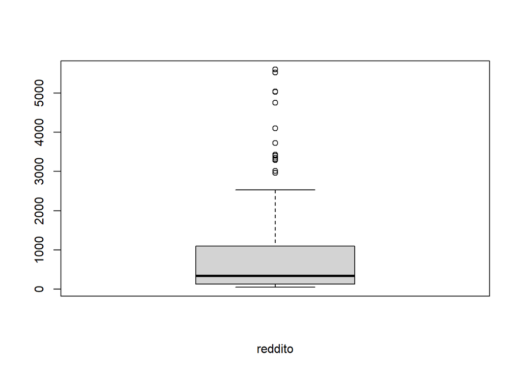

```r
# Boxplot della variabile reddito
boxplot(nazioni$reddito, main = "", xlab = "reddito")
```

```r
# Individuazione degli outlier
outlier_reddito <- boxplot.stats(nazioni$reddito)$out

outlier_reddito
```

```
##  [1] 3426 3346 4751 5029 3312 3403 5040 3292 4103 3723 4102 5596 2963 5523 3010
```

## 💥 Risposta

Sono stati individuati i valori anomali della variabile `reddito` utilizzando il metodo del *boxplot*.

I valori anomali della variabile `reddito` sono: **3426, 3346, 4751, 5029, 3312, 3403, 5040, 3292, 4103, 3723, 4102, 5596, 2963, 5523, 3010**.

### 🔹 Punto c)

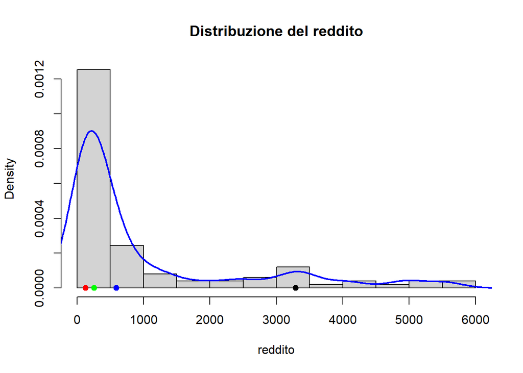

```r
# Istogramma del reddito
hist(nazioni$reddito,
     main = "Distribuzione del reddito",
     xlab = "reddito",
     col = "lightgray",
     probability = TRUE)

# Curva di densità (kernel)
lines(density(nazioni$reddito), col = "blue", lwd = 2)

# Mediane per area geografica
mediane <- tapply(nazioni$reddito, nazioni$areaGeo, median)

# Aggiunta delle mediane come punti
points(mediane, rep(0, length(mediane)),
       col = c("red","blue","green","black"),
       pch = 19)
```

## 💥 Risposta

La distribuzione del reddito è *asimmetrica a destra*, con una coda verso valori elevati.

### 🔹 Punto d)

```r
# Media
mean(nazioni$reddito)
```

```
## [1] 1005.929
```

```r
# Media troncata (10%)
mean(nazioni$reddito, trim = 0.1)
```

```
## [1] 711.9877
```

```r
# Mediana
median(nazioni$reddito)
```

```
## [1] 334
```

```r
# Skewness (calcolo manuale)
skewness <- mean((nazioni$reddito - mean(nazioni$reddito))^3) /
            sd(nazioni$reddito)^3

skewness
```

```
## [1] 1.758945
```

## 💥 Risposta

La **media** del reddito è pari a **1005.93**, la **media troncata** è pari a **711.99** e la **mediana** è pari a **334**.

Poiché la **media è maggiore della mediana**, si deduce che la distribuzione del reddito è *asimmetrica a destra*.

L’indice di *skewness* è pari a **1.76**, confermando una forte asimmetria positiva.

### 🔹 Punto e)

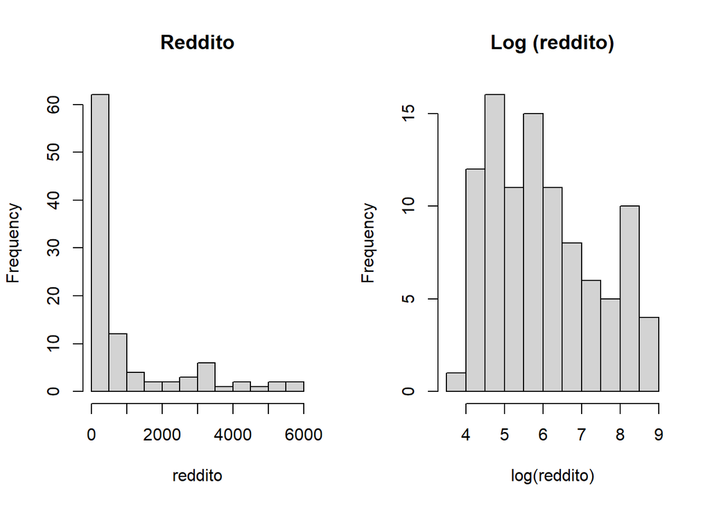

```r
# Trasformazione logaritmica
nazioni$log_reddito <- log(nazioni$reddito)

# Layout 1x2 per confronto
par(mfrow = c(1, 2))   # Per affiancare i due grafici

# Istogramma reddito originale
hist(nazioni$reddito,
     main = "Reddito",                 # Titolo
     xlab = "reddito",          # Etichetta asse x
     col = "lightgray")         # Colore barre

# Istogramma log(reddito)
hist(nazioni$log_reddito,
     main = "Log (reddito)",
     xlab = "log(reddito)",
     col = "lightgray")
```

```r
# Ripristino layout
par(mfrow = c(1, 1))   # Torna a 1 grafico

# Skewness su reddito trasformato
skew_log <- mean((nazioni$log_reddito - mean(nazioni$log_reddito))^3) /
            sd(nazioni$log_reddito)^3

skew_log
```

```
## [1] 0.4465576
```

## 💥 Risposta

La trasformazione logaritmica rende la distribuzione più *simmetrica*.

Lo skewness passa da **1.76** a **0.45**, riducendo l’asimmetria.

### 🔹 Punto f)

```r
# Deviazione standard per area geografica
tapply(nazioni$reddito, nazioni$areaGeo, sd)
```

```
##    Africa  Americas      Asia    Europe
##  514.3173 1406.0152 1002.6715 1481.4340
```

```r
# Range (max - min) per area geografica
tapply(nazioni$reddito, nazioni$areaGeo, function(x) max(x) - min(x))
```

```
##   Africa Americas     Asia   Europe
##     2960     5323     3650     5190
```

## 💥 Risposta

La dispersione del reddito è maggiore in **Europe** e **Americas**, mentre è più contenuta in **Africa**.

### 🔹 Punto g)

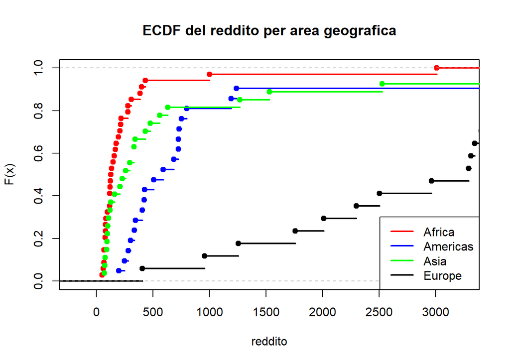

```r
# ECDF Africa
plot(ecdf(nazioni$reddito[nazioni$areaGeo == "Africa"]),
     col = "red",       # Colore linea
     lwd = 2,           # Spessore linea
     main = "ECDF del reddito per area geografica",         # Titolo
     xlab = "reddito",  # Etichetta asse x
     ylab = "F(x)")     # Etichetta asse y

# ECDF altre aree
lines(ecdf(nazioni$reddito[nazioni$areaGeo == "Americas"]),
      col = "blue", lwd = 2)

lines(ecdf(nazioni$reddito[nazioni$areaGeo == "Asia"]),
      col = "green", lwd = 2)

lines(ecdf(nazioni$reddito[nazioni$areaGeo == "Europe"]),
      col = "black", lwd = 2)

# Linea riferimento 5000
abline(v = 5000, lty = 2)   # Linea verticale tratteggiata

# Legenda
legend("bottomright",
       legend = c("Africa", "Americas", "Asia", "Europe"),
       col = c("red", "blue", "green", "black"),
       lwd = 2)
```

## 💥 Risposta

L’area **Africa** presenta una percentuale maggiore di nazioni con reddito inferiore a **5000 dollari**, seguita da **Asia** e **Americas**.

L’area **Europe** mostra invece redditi mediamente più elevati.

### 🔹 Punto h)

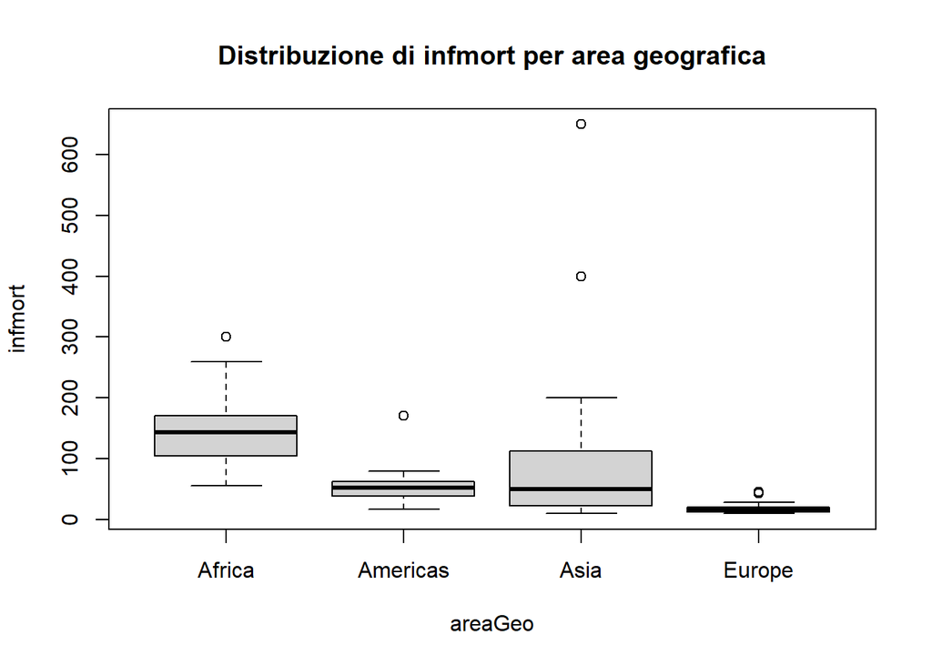

```r
# Boxplot della mortalità infantile per area geografica
boxplot(infmort ~ areaGeo, data = nazioni,
        main = "Distribuzione di infmort per area geografica",  # titolo
        xlab = "areaGeo",                                      # asse x
        ylab = "infmort",                                      # asse y
        col = "lightgray")                                     # colore box
```

## 💥 Risposta

La mortalità infantile è mediamente più elevata in **Africa**, mentre risulta più bassa in **Europe**.

L’area **Asia** presenta una maggiore variabilità, con presenza di valori molto elevati.

### 🔹 Punto i)

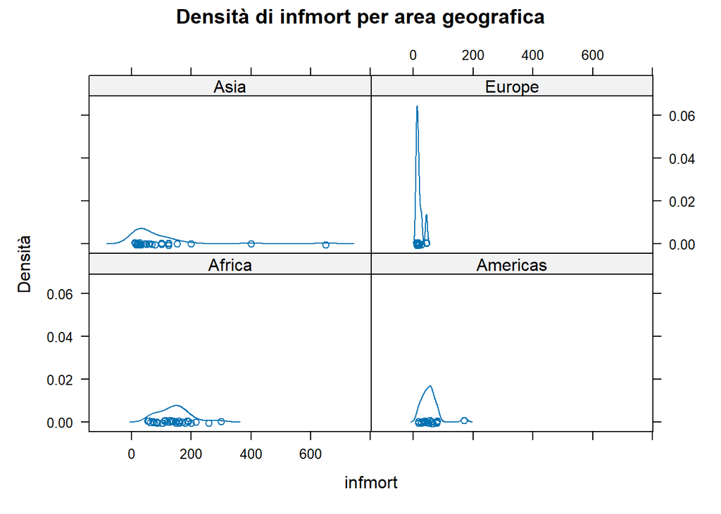

```r
# Libreria lattice
library(lattice)

# Densità condizionata
densityplot(~ infmort | areaGeo, data = nazioni,
            main = "Densità di infmort per area geografica",
            xlab = "infmort")
```

## 💥 Risposta

La distribuzione della mortalità infantile è più concentrata su valori bassi in **Europe** e **Americas**.

Le aree **Africa** e **Asia** mostrano invece distribuzioni più disperse, con presenza di valori più elevati.

### 🔹 Punto j)

```r
# Creazione redditoCat (quartili)
nazioni$redditoCat <- cut(nazioni$reddito,
                          breaks = quantile(nazioni$reddito,
                                            probs = seq(0, 1, 0.25)),
                          include.lowest = TRUE)

# Tabella distribuzioni condizionate
tab <- prop.table(table(nazioni$redditoCat, nazioni$oil), 2)

# Arrotondamento
round(tab, 2)
```

```
##
##                        1    2
##   [50,128]          0.26 0.12
##   (128,334]         0.25 0.25
##   (334,1.1e+03]     0.24 0.25
##   (1.1e+03,5.6e+03] 0.24 0.38
```

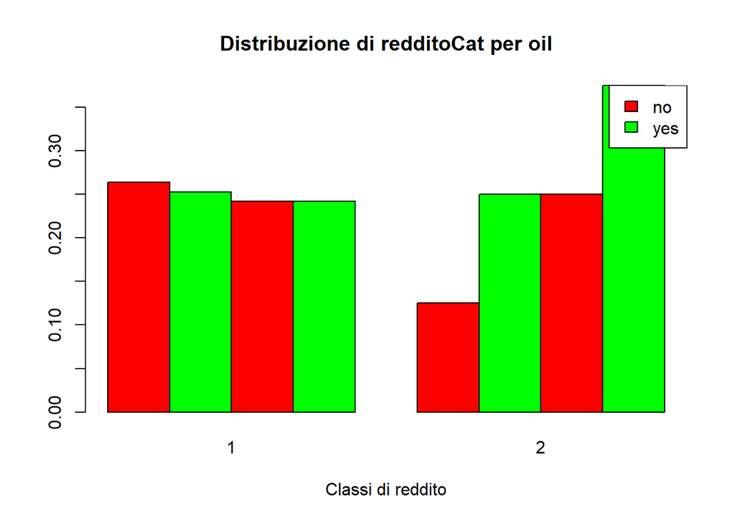

```r
# Grafico
barplot(tab,
        beside = TRUE,
        col = c("red", "green"),   # no = rosso, yes = verde
        main = "Distribuzione di redditoCat per oil",
        xlab = "Classi di reddito")

# Legenda
legend("topright",
       legend = c("no", "yes"),
       fill = c("red", "green"))
```

## 💥 Risposta

Tra i paesi esportatori di petrolio (**yes**) si osserva una maggiore concentrazione nelle classi di reddito più elevate.

I paesi non esportatori (**no**) risultano invece più distribuiti tra le classi di reddito più basse.

# Esercizio 2

Il dataset `insurance.csv` descrive le spese mediche sostenute da una compagnia assicurativa statunitense per 1338 soggetti.

Le variabili presenti nel dataset sono:

- `age`: età dell’assicurato
- `sex`: genere dell’assicurato
- `bmi`: indice di massa corporea
- `children`: numero di figli a carico
- `smoker`: fumatore
- `region`: area di residenza
- `charges`: spese mediche

Si svolgano i seguenti punti:

1. Rappresentare graficamente la distribuzione delle variabili categoriali evidenziando con un colore diverso la categoria più frequente.
2. In un unico grafico, ottenere i boxplot di `charges` rispetto a `children` (0, 1, 2, 3+), aggiungendo la media come barra rossa.
3. Creare la variabile `bmicat` e rappresentare gli istogrammi delle spese per ciascuna categoria.
4. Analizzare la relazione tra `bmicat` e `sex`.

## ✏️ Svolgimento

```r
# Caricamento dataset
insurance <- read.csv("insurance.csv")

# Struttura
str(insurance)
```

```
## 'data.frame':    1338 obs. of  8 variables:
##  $ X       : int  1 2 3 4 5 6 7 8 9 10 ...
##  $ age     : int  19 18 28 33 32 31 46 37 37 60 ...
##  $ sex     : chr  "female" "male" "male" "male" ...
##  $ bmi     : num  27.9 33.8 33 22.7 28.9 ...
##  $ children: int  0 1 3 0 0 0 1 3 2 0 ...
##  $ smoker  : chr  "yes" "no" "no" "no" ...
##  $ region  : chr  "southwest" "southeast" "southeast" "northwest" ...
##  $ charges : num  16885 1726 4449 21984 3867 ...
```

```r
# Controllo valori mancanti
colSums(is.na(insurance))
```

```
##        X      age      sex      bmi children   smoker   region  charges
##        0        0        0        0        0        0        0        0
```

### 🔹 Punto a)

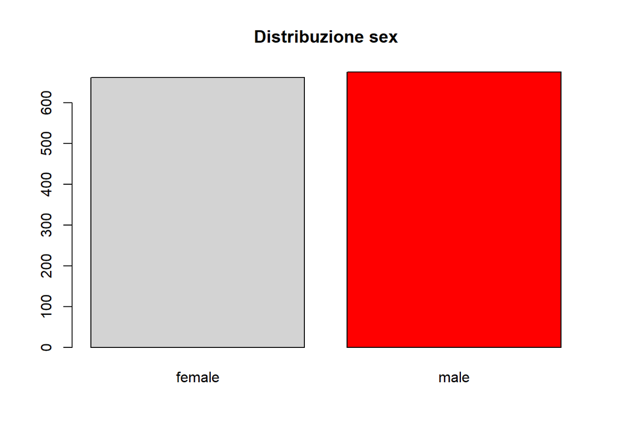

```r
# Variabili categoriali: sex, smoker, region

# SEX
tab_sex <- table(insurance$sex)
col_sex <- ifelse(tab_sex == max(tab_sex), "red", "lightgray")

barplot(tab_sex,
        col = col_sex,
        main = "Distribuzione sex")
```

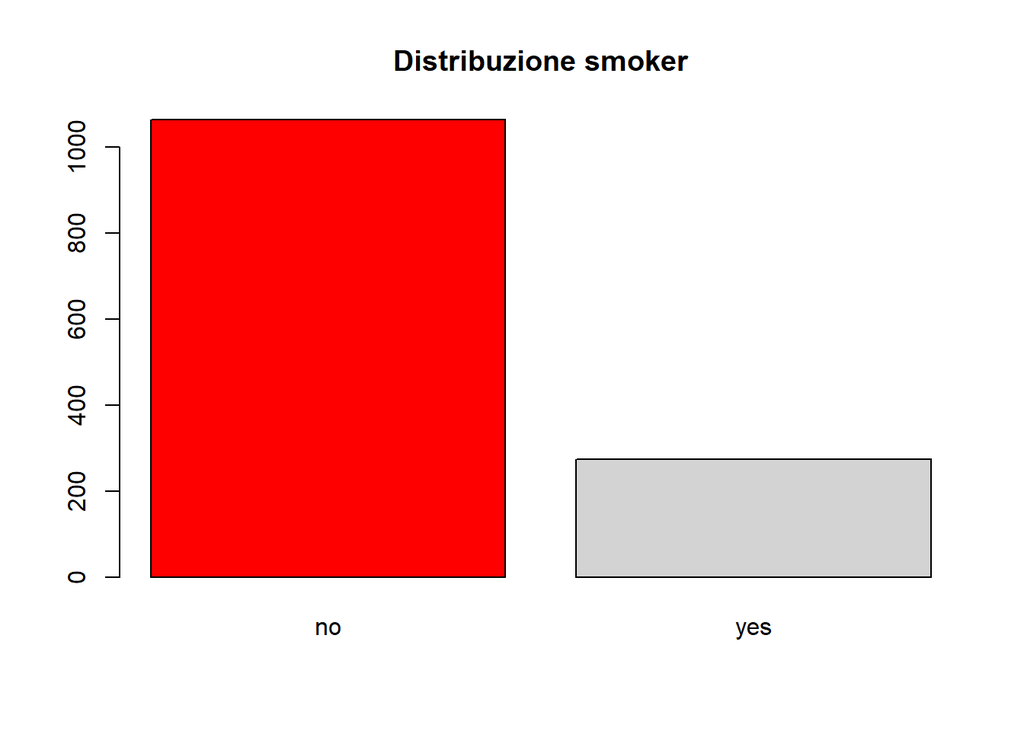

```r
# SMOKER
tab_smoker <- table(insurance$smoker)
col_smoker <- ifelse(tab_smoker == max(tab_smoker), "red", "lightgray")

barplot(tab_smoker,
        col = col_smoker,
        main = "Distribuzione smoker")
```

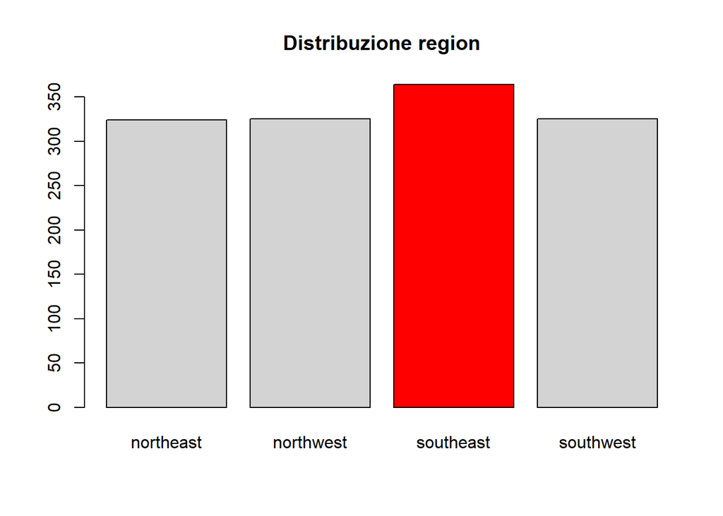

```r
# REGION
tab_region <- table(insurance$region)
col_region <- ifelse(tab_region == max(tab_region), "red", "lightgray")

barplot(tab_region,
        col = col_region,
        main = "Distribuzione region")
```

## 💥 Risposta

Per ciascuna variabile categoriale è stata rappresentata la distribuzione tramite diagramma a barre.

È stata evidenziata in rosso la categoria più frequente: **male** per `sex`, **no** per `smoker` e **southeast** per `region`.

### 🔹 Punto b)

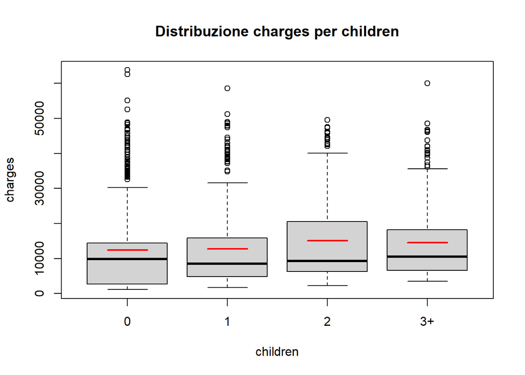

```r
# Creazione nuova variabile childrenCat
insurance$childrenCat <- ifelse(insurance$children >= 3, "3+", as.character(insurance$children))

# Boxplot
boxplot(charges ~ childrenCat, data = insurance,
        main = "Distribuzione charges per children",  # Titolo
        xlab = "children",                            # Asse x
        ylab = "charges",                             # Asse y
        col = "lightgray")                            # Colore box

# Media per ciascuna categoria
medie <- tapply(insurance$charges, insurance$childrenCat, mean)

# Aggiunta media come barre rosse
segments(x0 = 1:length(medie) - 0.2,
         x1 = 1:length(medie) + 0.2,
         y0 = medie,
         y1 = medie,
         col = "red",   # Colore media
         lwd = 2)       # Spessore linea
```

### 🔹 Punto c)

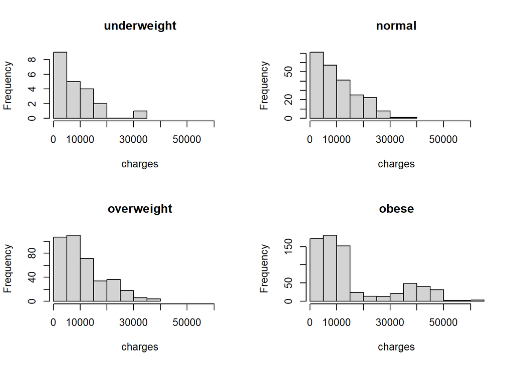

```r
# Creazione bmicat
insurance$bmicat <- cut(insurance$bmi,
                        breaks = c(-Inf, 18.5, 25, 30, Inf),
                        labels = c("underweight", "normal", "overweight", "obese"))

# Layout 2x2
par(mfrow = c(2, 2))   # 4 grafici

# Istogrammi per categoria
for(cat in levels(insurance$bmicat)) {
  hist(insurance$charges[insurance$bmicat == cat],
       main = cat,                       # Titolo
       xlab = "charges",
       col = "lightgray",
       xlim = range(insurance$charges))  # Stessa scala asse x
}
```

```r
# Ripristino
par(mfrow = c(1, 1))
```

## 💥 Risposta

Le spese mediche tendono ad aumentare al crescere della categoria di BMI.

In particolare, la categoria **obese** presenta valori mediamente più elevati e maggiore variabilità rispetto alle altre.

### 🔹 Punto d)

```r
# Tabella di contingenza
tab_bmi_sex <- table(insurance$bmicat, insurance$sex)

# Frequenze condizionate (per sesso)
tab_rel <- prop.table(tab_bmi_sex, 2)

round(tab_rel, 2)
```

```
##
##               female male
##   underweight   0.02 0.01
##   normal        0.18 0.16
##   overweight    0.30 0.28
##   obese         0.50 0.55
```

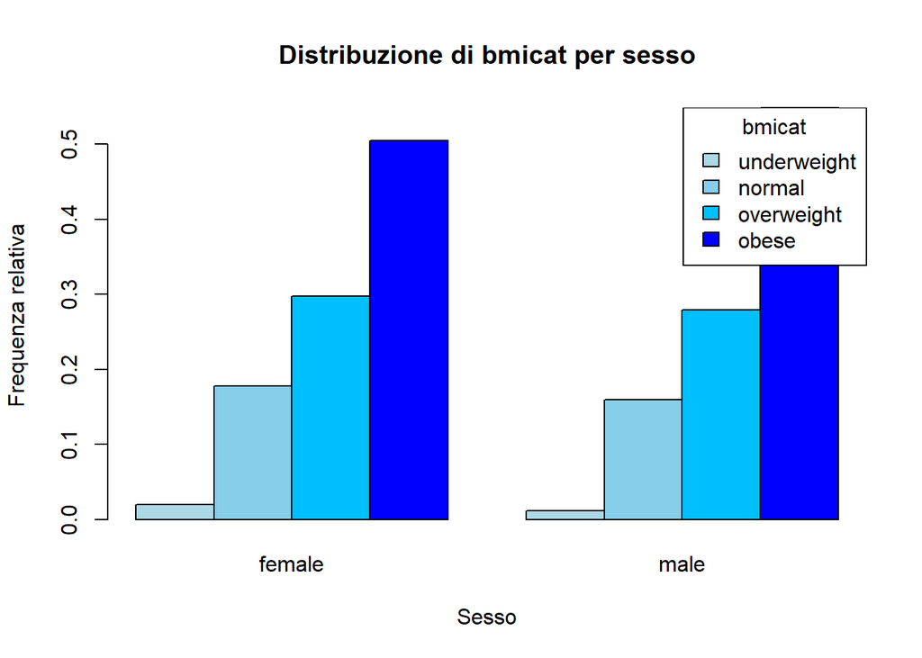

```r
# Colori progressivi (dal chiaro allo scuro)
colori <- c("lightblue", "skyblue", "deepskyblue", "blue")

# Grafico
barplot(tab_rel,
        beside = TRUE,
        col = colori,
        main = "Distribuzione di bmicat per sesso",
        xlab = "Sesso",
        ylab = "Frequenza relativa")

# Legenda
legend("topright",
       legend = rownames(tab_rel),
       fill = colori,
       title = "bmicat")
```

## 💥 Risposta

La distribuzione delle categorie di BMI è simile tra i due sessi, indicando una debole associazione tra `bmicat` e `sex`.

Si osserva una leggera maggiore presenza della categoria **obese** tra i **male**, ma le differenze complessive sono limitate.

# Esercizio 3

Si consideri il seguente dataset (file `.txt`) che riporta il livello di istruzione e la destinazione lavorativa.

Si svolgano i seguenti punti:

1. Costruire la tabella di contingenza tra livello di istruzione e destinazione lavorativa.
2. Calcolare le distribuzioni marginali.
3. Calcolare le distribuzioni condizionate.
4. Rappresentare graficamente i risultati ottenuti.

## ✏️ Svolgimento

```r
# Creazione manuale del dataset (da tabella fornita)
istruzione <- c("Laurea", "Diploma", "Media", "Elementare")

dati <- matrix(c(
  2829, 433, 394, 431, 401,
  9201, 1092, 733, 691, 1256,
  14764, 877, 531, 337, 1652,
  14759, 1119, 71, 42, 319
), nrow = 4, byrow = TRUE)

colnames(dati) <- c("Casa", "Mensa", "Rist", "Bar", "PostoLav")
rownames(dati) <- istruzione

dati
```

```
##             Casa Mensa Rist Bar PostoLav
## Laurea      2829   433  394 431      401
## Diploma     9201  1092  733 691     1256
## Media      14764   877  531 337     1652
## Elementare 14759  1119   71  42      319
```

## 💥 Risposta

La tabella di contingenza tra livello di istruzione e destinazione lavorativa è stata costruita correttamente.

### 🔹 Punto b)

```r
# Marginale per istruzione (righe)
margin.table(dati, 1)
```

```
##     Laurea    Diploma      Media Elementare
##       4488      12973      18161      16310
```

```r
# Marginale per destinazione (colonne)
margin.table(dati, 2)
```

```
##     Casa    Mensa     Rist      Bar PostoLav
##    41553     3521     1729     1501     3628
```

## 💥 Risposta

La distribuzione marginale mostra che il livello di istruzione più frequente è **Media**, mentre la destinazione lavorativa più comune è **Casa**.

### 🔹 Punto c)

```r
# Distribuzioni condizionate per istruzione (righe)
round(prop.table(dati, 1), 2)
```

```
##            Casa Mensa Rist  Bar PostoLav
## Laurea     0.63  0.10 0.09 0.10     0.09
## Diploma    0.71  0.08 0.06 0.05     0.10
## Media      0.81  0.05 0.03 0.02     0.09
## Elementare 0.90  0.07 0.00 0.00     0.02
```

```r
# Distribuzioni condizionate per destinazione (colonne)
round(prop.table(dati, 2), 2)
```

```
##            Casa Mensa Rist  Bar PostoLav
## Laurea     0.07  0.12 0.23 0.29     0.11
## Diploma    0.22  0.31 0.42 0.46     0.35
## Media      0.36  0.25 0.31 0.22     0.46
## Elementare 0.36  0.32 0.04 0.03     0.09
```

## 💥 Risposta

Condizionando per livello di istruzione, si osserva che all’aumentare del titolo di studio diminuisce la quota di persone che restano a **Casa**.

Condizionando per destinazione lavorativa, si nota che le attività come **Rist** e **Bar** sono associate principalmente a livelli di istruzione più elevati.

### 🔹 Punto d)

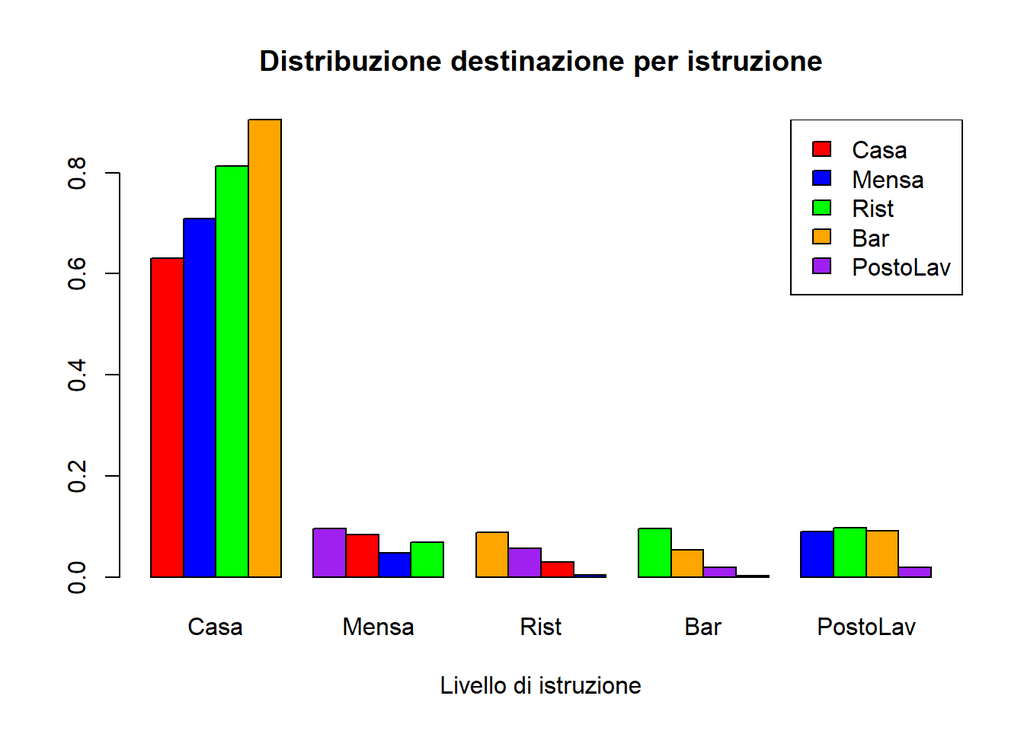

```r
# Colori distinti per le destinazioni
colori <- c("red", "blue", "green", "orange", "purple")

# Grafico distribuzioni per istruzione
barplot(prop.table(dati, 1),
        beside = TRUE,                         # Barre affiancate
        col = colori,                          # Colori barre
        main = "Distribuzione destinazione per istruzione",  # Titolo
        xlab = "Livello di istruzione")        # Asse x

# Legenda
legend("topright",
       legend = colnames(dati),               # Nomi destinazioni
       fill = colori)                         # Colori legenda
```

## 💥 Risposta

Si osserva che la destinazione **Casa** è prevalente per tutti i livelli di istruzione, in particolare per i livelli più bassi.

Le altre destinazioni risultano meno frequenti e mostrano una maggiore presenza tra i livelli di istruzione più elevati.